# Swiftkey Milestone Report

Shaaz Siddiqi

14/06/2016

### Introduction

The purpose of this document is just to display that exploring data and plan about app and algorithm.

Data files named LOCALE.blogs.txt, LOCALE.news.txt and LOCALE.twitter.txt where LOCALE is the each of the four locales en_US, de_DE, ru_RU and fi_FI. The data is from a corpus called HC Corpora (www.corpora.heliohost.org).

See the readme file at http://www.corpora.heliohost.org/aboutcorpus.html for details on the corpora available.

### Preparing The Data

1. Download data file

```r
DATA_PATH = 'E:/Desktop/final/'
SK.download <- function(){
    if(!file.exists(DATA_PATH)){
        dir.create(DATA_PATH)
        localPath <- paste(DATA_PATH, "data.zip", sep = "/")
        sourceUrl <- "https://d396qusza40orc.cloudfront.net/dsscapstone/dataset/Coursera-SwiftKey.zip"
        download.file(sourceUrl, localPath, method="curl")
        unzip(localPath, exdir = DATA_PATH)
    }
}
downloadedFilePath = paste(DATA_PATH, "final", sep = "/")
```

2. Basic Data Information
- The en_US.blogs.txt file contains 899288 lines and 37332736 words.
- The en_US.news.txt file contains 1010242 lines and 34372530 words.
- The en_US.twitter.txt file contains 2360148 lines and 30373543 words.
3. Load Data From Text File.
- I use `en_US` locale and blogs data only on this document (for reducing time)

```r
blogsTxtPath <- paste(downloadedFilePath, "en_US", "en_US.blogs.txt", sep = "/")
blogs <- readLines(blogsTxtPath, 10000)
```

### Cleaning & Exploring The Data

Using `tm` package for cleaning some words - remove whitespace - remove punctuation - convert to lowercase

```r
blogs.corpus <- VCorpus(VectorSource(blogs))
blogs.corpus <- tm_map(blogs.corpus, stripWhitespace)
blogs.corpus <- tm_map(blogs.corpus, removeNumbers)
blogs.corpus <- tm_map(blogs.corpus, removePunctuation)
blogs.corpus <- tm_map(blogs.corpus, content_transformer(tolower))
```

### Tokenization Of The Data

Make 3 types of tokenizer. a word, two words and three words.

```r
uniGramTokenizer <- function(x) NGramTokenizer(x, Weka_control(min = 1, max = 1))
biGramTokenizer <- function(x) NGramTokenizer(x, Weka_control(min = 2, max = 2))
triGramTokenizer <- function(x) NGramTokenizer(x, Weka_control(min = 3, max = 3))

uniWord <- TermDocumentMatrix(blogs.corpus, control = list(tokenize = uniGramTokenizer))
biWords <- TermDocumentMatrix(blogs.corpus, control = list(tokenize = biGramTokenizer))
triWords <- TermDocumentMatrix(blogs.corpus, control = list(tokenize = triGramTokenizer))
```

### Frequency Of Words

Calucate frequency 30 words

```r
calcFrequency <- function(gramTDM){
  freqTerms <- findFreqTerms(gramTDM, lowfreq = 50)
  freq <- rowSums(as.matrix(gramTDM[freqTerms,]))
  freq <- data.frame(word=names(freq), freq=freq)
  freq[order(-freq$freq), ][1:30, ]
}
```

### Unigram Plot

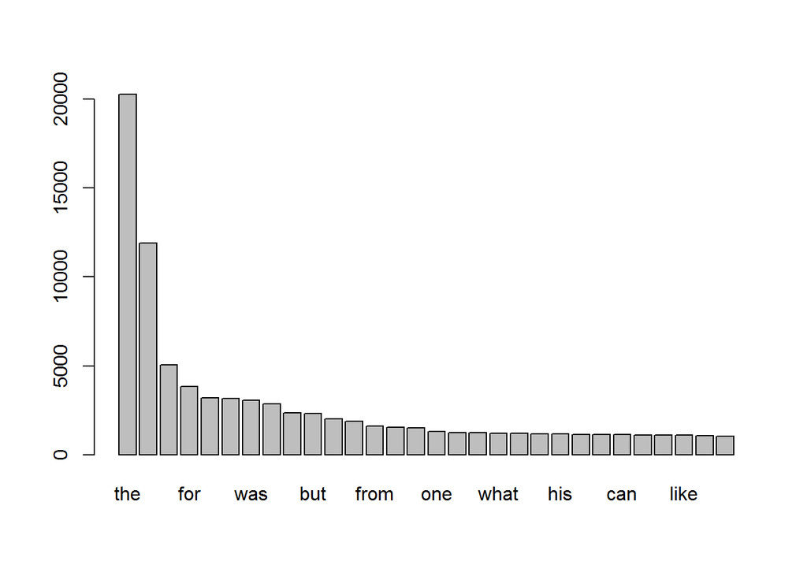

```r
unigram <- calcFrequency(uniWord)
barplot(unigram$freq, names.arg=unigram$word)
```

```r
unigram[1:10, ]
```

```
##      word  freq
## the   the 20282
## and   and 11912
## that that  5040
## for   for  3845
## with with  3188
## you   you  3164
## was   was  3073
## this this  2845
## have have  2343
## but   but  2317
```

### Bigram Plot

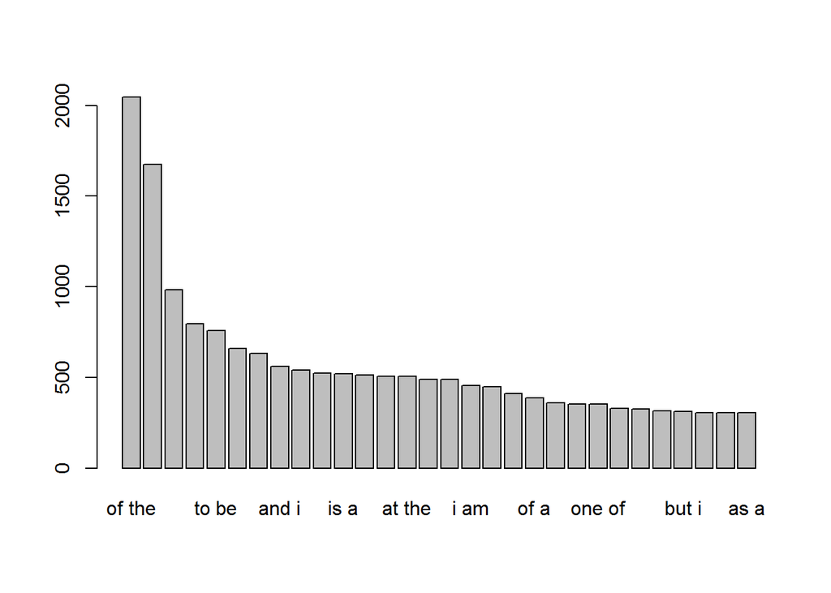

```r
bigram <- calcFrequency(biWords)
barplot(bigram$freq, names.arg=bigram$word)
```

```r
bigram[1:10, ]
```

```
##            word freq
## of the   of the 2047
## in the   in the 1674
## to the   to the  982
## on the   on the  795
## to be     to be  759
## and the and the  659
## for the for the  631
## and i     and i  560
## i was     i was  541
## it was   it was  524
```

### Trigram Plot

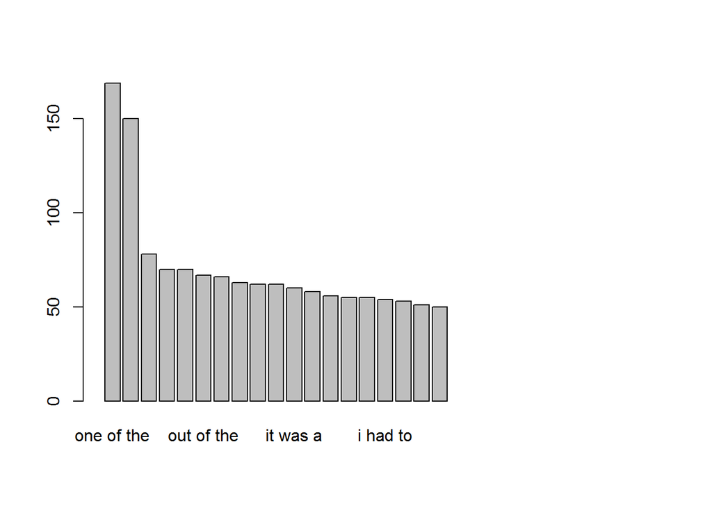

```r
trigram <- calcFrequency(triWords)
barplot(trigram$freq, names.arg=trigram$word)
```

```r
trigram[1:10, ]
```

```
##                    word freq
## one of the   one of the  169
## a lot of       a lot of  150
## to be a         to be a   78
## as well as   as well as   70
## some of the some of the   70
## out of the   out of the   67
## the end of   the end of   66
## i want to     i want to   63
## a couple of a couple of   62
## part of the part of the   62
```

### Plans For Prediction Application

- Text input on application for entering sentence.
- When user press spacebar or click submit button, app recommends words on label
- After user press spacebar app calculate next word.
- I will use ‘tm’ package for processing data.
- I will make 2-gram, 3-gram or 4-gram dataset.
- Application get words from user, it finds next word from n-gram dataset